# Mémoire

- Montrer tous les codes
- Cacher tous les codes
- Voir les sources

Auteur

Fatima Akkoubi

Date De Publication

18 mai 2022

```r
dat <- read.csv(paste0("data/", "dat.csv"),
  header = TRUE,
  sep = ",",
  dec = ".",
  stringsAsFactors = TRUE
  # , na.strings = c("", " ", "NA")
)

## Reordering dat$Groupe
dat$Groupe <- factor(dat$Groupe,
  levels = c("Ecouteur classique", "ActiveVent")
)

# View(dat)
# str(dat)
```

# 1 Résumé des tests statistiques pour comparaison de groupes ou temps

Pour rappel, ci-dessous un tableau récapitulatif reprenant les différents tests statistiques utilisés pour comparer deux groupes/temps ou plus, ainsi que les cas dans lesquels ils sont utilisés :

| Comparaison entre | Type | Test |
| --- | --- | --- |
| 2 groupes indépendants | Paramétrique | Test de Student (aussi appelé t-test) |
| 2 groupes indépendants | Non-paramétrique | Test de Mann-Whitney |
| 2 groupes dépendants | Paramétrique | Test de Student pour données pairées |
| 2 groupes dépendants | Non-paramétrique | Test de Wilcoxon pour données pairées |
| Plus de 2 groupes indépendants | Paramétrique | ANOVA |
| Plus de 2 groupes indépendants | Non-paramétrique | Kruskal-Wallis |
| Plus de 2 groupes dépendants | Paramétrique | ANOVA à mesures répétées |
| Plus de 2 groupes dépendants | Non-paramétrique | Friedman test |

Notons que les tests paramétriques sont utilisés pour des grands échantillons (à partir de 30 observations par groupe, grâce au théorème central limite) et les tests non-paramétriques sont utilisés pour les petits échantillons (Ghasemi et Zahediasl 2012).

Voir cet [arbre décisionnel](https://statsandr.com/blog/files/overview-statistical-tests-statsandr.pdf) pour un récapitulatif plus détaillé des différents tests statistiques en fonction du type de variable.

# 2 Comparaison des 2 appareils auditifs

Dans ce qui suit, nous comparons les 2 appareils auditifs pour chaque mesure. Etant donné que les patients ont été mesurés avec l’écouteur classique **et** l’ActiveVent, nous avons des échantillons **dépendants**. De plus, nous avons une petite taille d’échantillon, nous utilisons donc le test de Wilcoxon pour données pairées.

Nous faisons un boxplot pour représenter visuellement les données et nous appliquons ce test pour chaque mesure l’une à la suite de l’autre.

Un boxplot (appelé aussi boîte à moustaches) permet de visualiser les données. Notons que la ligne grasse dans la boîte représente la médiane (i.e., la valeur qui divise en deux parts égales les données, c’est-à-dire qu’il y a 50% des observations en-dessous de cette valeur et 50% au-dessus de cette valeur). Des boxplots qui se trouvent à la même hauteur laisse supposer que les groupes ne sont pas différents. Au contraire, des boxplots qui se trouvent à des hauteurs radicalement différentes laisse supposer que les groupes sont différents. Cependant, seul un test statistique permet d’appliquer ces suppositions faites depuis le graphique sur la population.

La $p$-valeur du test est affichée au-dessus du graphique (c’est la valeur qui se trouve après `p =`, les autres valeurs sont moins intéressantes dans le cadre de ton mémoire). Pour rappel, une $p$-valeur en-dessous du seuil de significativité $\alpha$ = 0.05 (i.e., $p$-value < 0.05) signifie qu’on rejette l’hypothèse nulle, tandis qu’une $p$-valeur égale ou au-dessus de ce seuil de significativité $\alpha$ = 0.05 (i.e., $p$-value $\ge$ 0.05) signifie qu’on ne rejette pas l’hypothèse nulle. Enfin, voici l’hypothèse nulle et l’hypothèse alternative du test :

- $H_0$: pas de différence significative
- $H_1$: différence significative

Les résultats impliquent que si l’on rejette l’hypothèse nulle (parce que la $p$-valeur < 0.05), on peut considérer que les distributions sont significativement différentes, tandis que si l’on ne rejette pas l’hypothèse nulle (parce que la $p$-valeur $\geq$ 0.05), ceci implique que les données ne nous permettent pas de rejeter le fait que les distributions sont les mêmes et on ne peut donc pas conclure à une différence significative.

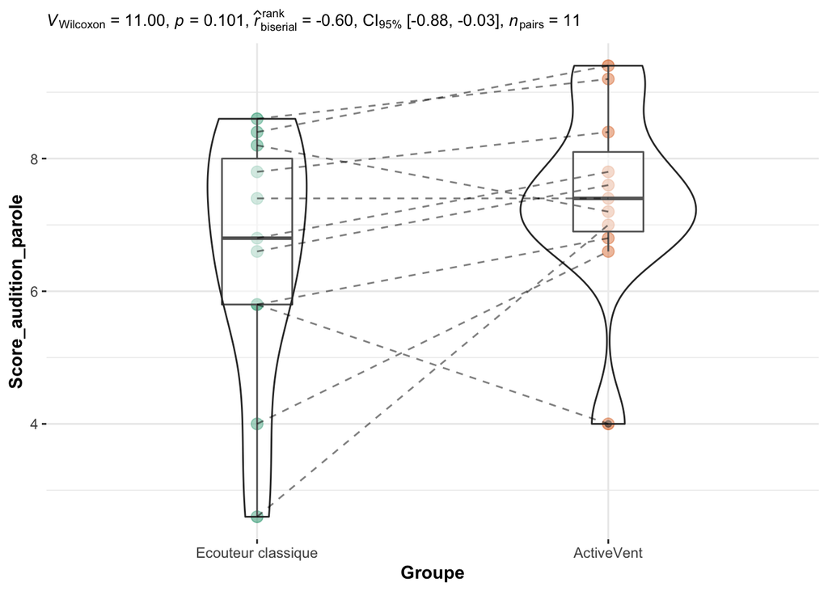

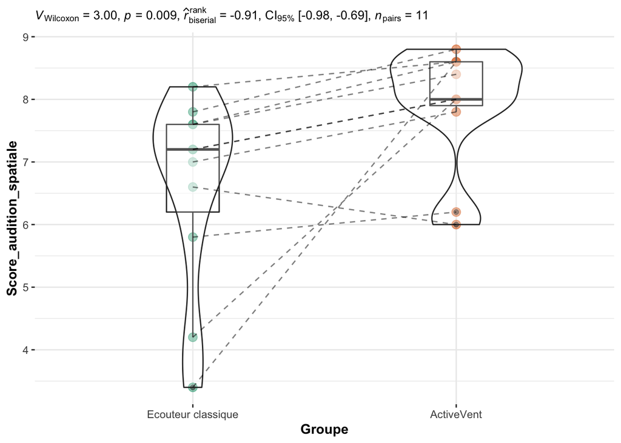

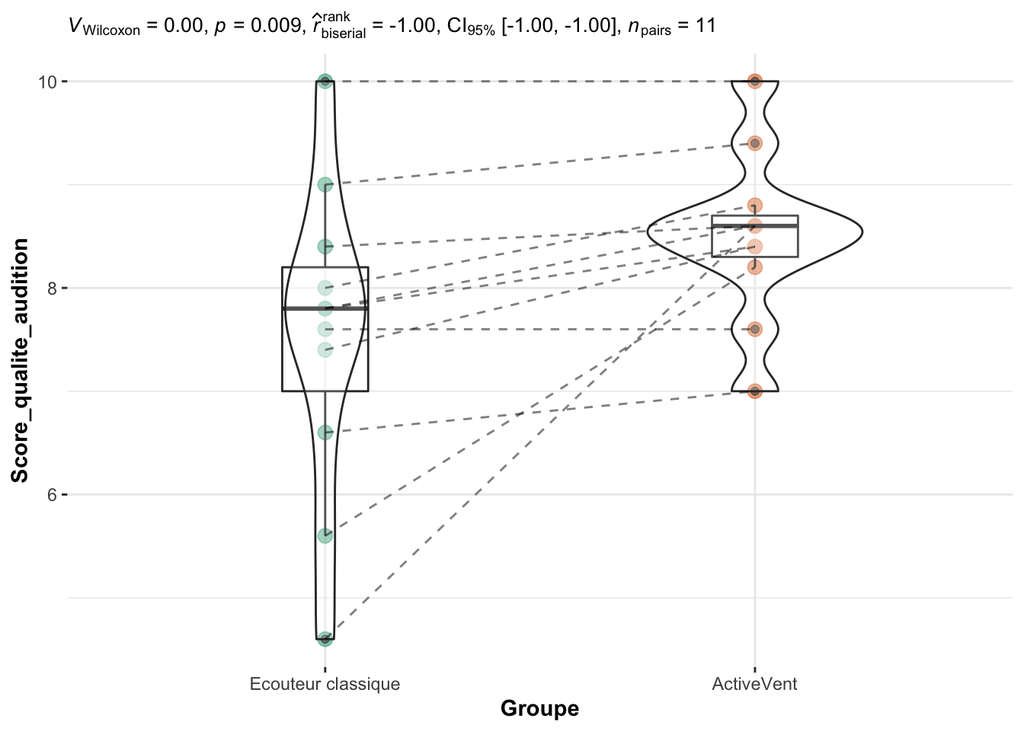

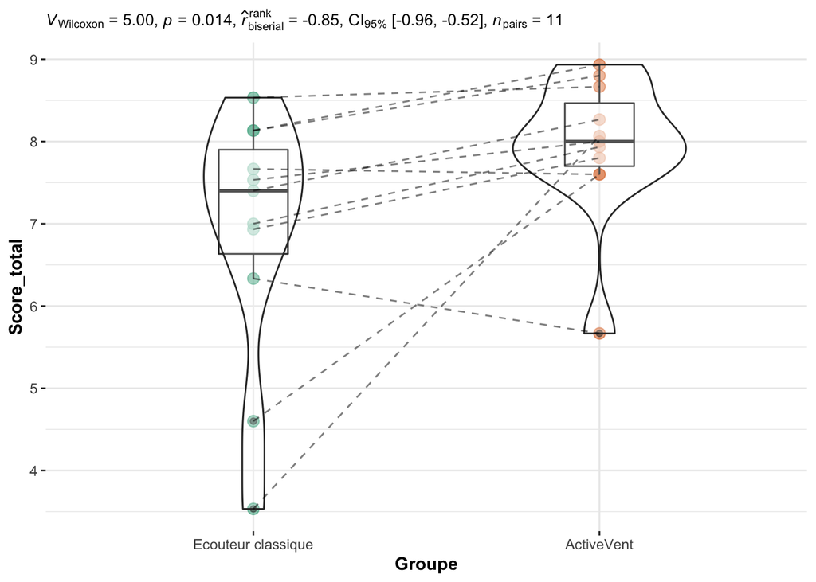

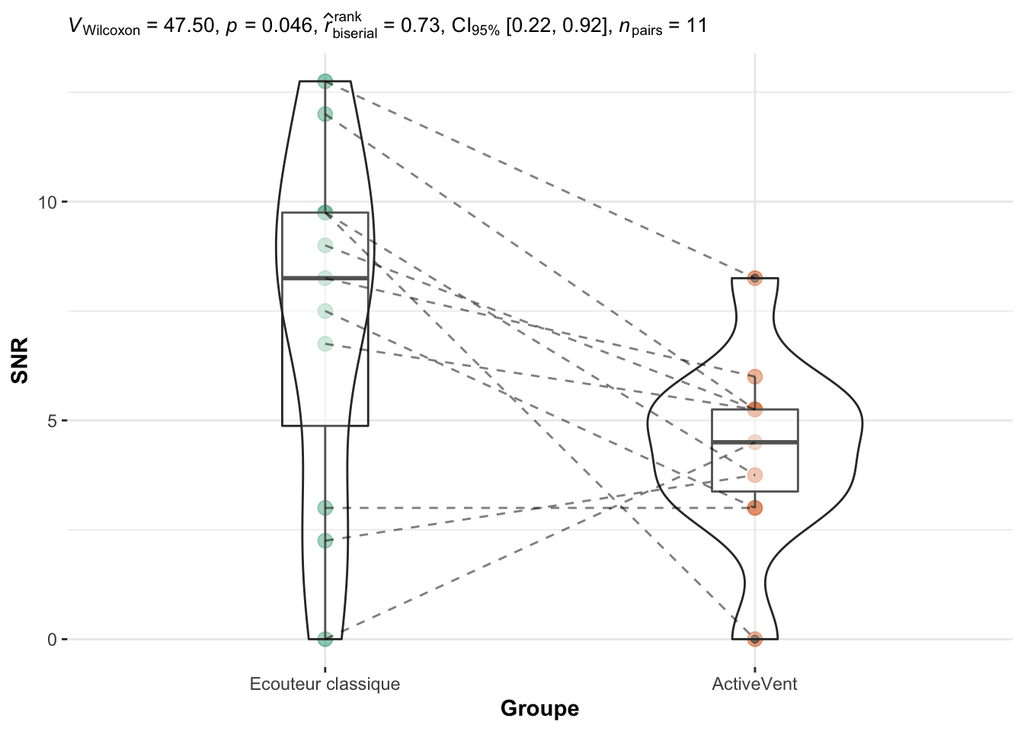

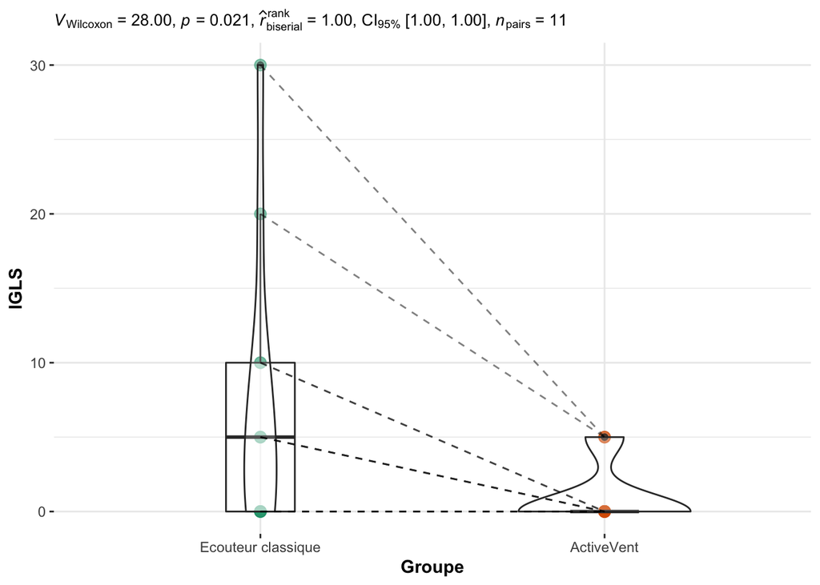

```r
# to edit #
x <- "Groupe"
start_y <- 2
paired <- TRUE
# to edit #

type <- ifelse(
  min(table(dat[, x])) < 30,
  "nonparametric",
  "parametric"
)

plotlist <-
  purrr::pmap(
    .l = list(
      data = list(as_tibble(dat)),
      x = x,
      # y = list("Var1", "Var2", "Var3"),
      y = as.list(colnames(dat)[start_y:ncol(dat)]),
      plot.type = "box",
      type = type,
      pairwise.comparisons = TRUE,
      pairwise.display = "significant",
      bf.message = FALSE,
      # nboot = 1L,
      centrality.plotting = FALSE
    ),
    .f = ifelse(paired,
                ggstatsplot::ggwithinstats,
                ggstatsplot::ggbetweenstats)
  )

for (i in 1:length(plotlist)) {
  print(plotlist[[i]] + labs(caption = NULL))
}
```

**Interprétations statistiques**

Sur base des résultats des tests :

- Score audition parole : on ne rejette pas l’hypothèse que le score d’audition de parole est le même entre les 2 écouteurs ($p$-valeur = 0.101).
- Score audition spatiale : on conclut que le score d’audition spatiale est différent entre les 2 écouteurs ($p$-valeur = 0.009). Au vu du graphique, on conclut que le score est plus élevé pour ActiveVent.
- Score qualité audition : on conclut que le score de qualité d’audition est différent entre les 2 écouteurs ($p$-valeur = 0.009). Au vu du graphique, on conclut que le score est plus élevé pour ActiveVent.
- Score total : on conclut que le score total est différent entre les 2 écouteurs ($p$-valeur = 0.014). Au vu du graphique, on conclut que le score est plus élevé pour ActiveVent.
- SNR : on conclut que SNR est différent entre les 2 écouteurs ($p$-valeur = 0.046). Au vu du graphique, on conclut que SNR est plus bas pour ActiveVent.
- IGLS : on conclut que IGLS est différent entre les 2 écouteurs ($p$-valeur = 0.021). Au vu du graphique, on conclut que IGLS est plus bas pour ActiveVent.

# 3 Ressources supplémentaires

Ci-dessous des ressources supplémentaires (en anglais) qui aideront à mieux comprendre les analyses faites dans ce travail:

- [Quel test statistique dois-je faire ?](https://statsandr.com/blog/what-statistical-test-should-i-do/)
- [Test de Mann-Whitney et test de Wilcoxon](https://statsandr.com/blog/wilcoxon-test-in-r-how-to-compare-2-groups-under-the-non-normality-assumption/)

# 4 Programme

Tous les graphiques et analyses ont été faits sur le programme R version 4.1.1 (2021-08-10).

## Les références

Ghasemi, Asghar, et Saleh Zahediasl. 2012. « Normality tests for statistical analysis: a guide for non-statisticians ». *International journal of endocrinology and metabolism* 10 (2): 486.